# Shared plant knowledge in a camp

Pascal Bärtschi

2023-09-06

# Introduction

In this markdown, we will analyze shared plant knowledge among a group of individuals. We have two main datasets: one containing information about plant knowledge and another containing information about the participants. Our goal is to understand the factors that influence shared plant knowledge within dyads (pairs of participants). The data was taken from the research of [Salali et al. (2020)](https://osf.io/udwzr/).

# Loading Data and Libraries

We begin by loading the necessary R libraries and the datasets containing our data. We’ll load the required packages for data wrangling, visualization, and modeling.

```r
# Load required libraries
suppressPackageStartupMessages({library(tidyverse) # For data wrangling
                                library(ggplot2)# For data visualization
                                library(lme4) # For mixed-effects models
  })
```

```r
# Load the plant knowledge dataset
know <- read.csv("plant_knowledge.csv")

# Load the participants dataset
people <- read.csv("plant_participants.csv")

# Rename the ID entry
names(know)[1] <- "ID"
names(people)[1] <- "ID"
```

# Exploratory Data Analysis

## Plant Knowledge Dataset

### Dataset Dimensions

Let’s start by exploring the dimensions of our plant knowledge dataset. This will help us understand how many subjects and plants are included in our analysis.

```r
# Number of subjects in the dataset
print(paste("Subjects: ", nrow(know)))
```

```
## [1] "Subjects:  219"
```

```r
# Number of plants in the dataset
print(paste("Plants: ", ncol(know) - 1))
```

```
## [1] "Plants:  33"
```

### Sum of Knowledge by Plant

Next, we’ll calculate the sum of plant knowledge across all participants for each plant species. This will give us insights into which plants are known by a larger number of people.

```r
# Create a data frame with the sum of knowledge for each plant
frame_know_plant <- data.frame(know_count = sort(colSums(know[,-1]), decreasing = TRUE))

# Print the data frame
print(frame_know_plant)
```

```
##           know_count
## Mobey            216
## Ekoka            215
## Mokakake         214
## Guka             213
## Banga            212
## Boyo             211
## Kombo            208
## Kokosa           201
## Kungu            199
## Imbanda          198
## Ngata            198
## Mongangai        196
## Jongo            195
## Indengo          189
## Bulaki           185
## Iboko            183
## Mosombo          183
## Moba             180
## Embondo          178
## Mokula           177
## Mongo            173
## Juese            171
## Mongamba         164
## Mopo             162
## Njobe            161
## Imbenya          149
## Mototoko         149
## Toko             146
## Muese            144
## Imbi             134
## Mokata           132
## Somboli          101
## Euey              92
```

```r
# Calculate and print the average plant knowledge
print(paste("Plant knowledge avg:", mean(frame_know_plant$know_count)))
```

```
## [1] "Plant knowledge avg: 176.636363636364"
```

```r
# Identify plants known by over 200 people
print("Plants known by over 200 people:")
```

```
## [1] "Plants known by over 200 people:"
```

```r
print(rownames(frame_know_plant %>% filter(know_count > 200)))
```

```
## [1] "Mobey"    "Ekoka"    "Mokakake" "Guka"     "Banga"    "Boyo"     "Kombo"
## [8] "Kokosa"
```

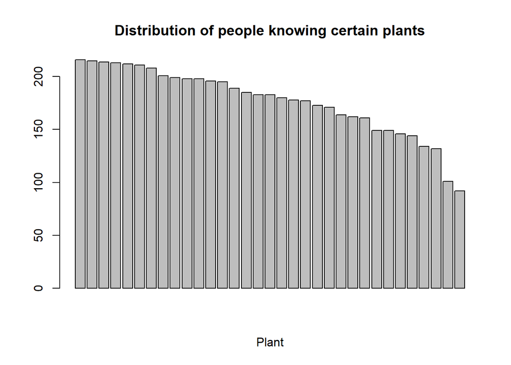

```r
# Create a bar plot to visualize the distribution of people knowing certain plants
barplot(frame_know_plant$know_count,
        main = "Distribution of people knowing certain plants",
        xlab = "Plant")
```

## Plant Participants Dataset

### Age Distribution

Let’s explore the age distribution of the participants.

```r
# Create a table of age counts
age_counts <- table(people$age)

# Print the table
print(age_counts)
```

```
##
## 05-10 10-15 15-20 20-25 25-30 30-35 35-40 40-60 60-80
##     7    15    26    29    30    24    23    41    21
```

### Fraction of Pre-adults

We’ll calculate the fraction of pre-adult participants (ages 5-10 and 10-15) among all participants.

```r
# Count of participants aged 5-10 or 10-15
count_pre_20 <- people %>% filter(age == "05-10" | age == "10-15") %>% nrow()

# Calculate and print the fraction of pre-adults
print(count_pre_20 / nrow(people))
```

```
## [1] 0.1004566
```

### Sex Ratio

Let’s calculate the sex ratio among the participants.

```r
# Count of male participants
count_males <- people %>% filter(sex == "M") %>% nrow()

# Count of female participants
count_females <- people %>% filter(sex == "F") %>% nrow()

# Calculate and print the sex ratio (Males / Females)
print(paste("Sex ratio M/F:", count_males / count_females))
```

```
## [1] "Sex ratio M/F: 0.831932773109244"
```

# Data wrangling: merge files to create dyad dataframe

We will create dyads by combining participants from the participants dataset and then merge the dyads with plant knowledge information. The idea is to analyse the shared knowledge of two people and see whether shared knowledge shows a relationship with with dyadic:

- sex
- age
- birthplace
- or camp

First we merge the two dataframes as follows:

```r
# Create dyads by combining participants
dyads <- data.frame(t(combn(people$ID, 2)))

# Calculate the number of possible dyads
no_dyads <- length(people$ID) * (length(people$ID) - 1) / 2

# Calculate the number of plant species
no_plants <- ncol(know) - 1

# Add dyad names and rename columns
dyads$dyad_ID <- paste(dyads$X1, dyads$X2, sep = "_")
colnames(dyads) <- c("ID1", "ID2", "dyad_ID")

# Merge dyads with participant information
dyads_people <- merge(dyads, people, by.x = "ID2", by.y = "ID")
dyads_people <- merge(dyads_people, people, by.x = "ID1", by.y = "ID")

# Create a variable to represent dyad sex (combination of sex of participants)
dyads_people$dyadsex <- paste0(pmin(dyads_people$sex.x, dyads_people$sex.y),
                               pmax(dyads_people$sex.x, dyads_people$sex.y))

# Create a variable to represent if dyads have the same sex
dyads_people$samesex <- ifelse(dyads_people$dyadsex == "FM", 1, 0)

# Switch from wide to long format for plant knowledge data
know <- know %>% gather("plant", "know", -ID)

# Merge dyads with plant knowledge data
dyads_merged <- merge(dyads_people, know, by.x = "ID1", by.y = "ID")
dyads_merged <- merge(dyads_merged, know, by.x = c("ID2", "plant"), by.y = c("ID", "plant"))

# Check if the dimensions of the merged data frame are as expected
print(paste("Check dimension of frame:", nrow(dyads_merged) == no_dyads * no_plants))
```

```
## [1] "Check dimension of frame: TRUE"
```

```r
# Reorder columns and rename them for clarity
dyads_merged <- dyads_merged %>%
  select(c(3, 1, 4, 5, 11, 6, 12, 18, 17, 7, 13, 8, 14, 9, 15, 2, 19, 20, 10, 16)) %>%
  rename_with(~gsub(".x","1", .x, fixed = TRUE)) %>%
  rename_with(~gsub(".y","2", .x, fixed = TRUE))

# Check the df
dyads_merged %>% head()
```

```
##    ID1  ID2   dyad_ID camp1 camp2 sex1 sex2 samesex dyadsex  age1  age2
## 1 M001 M025 M001_M025   CML   CML    F    M       1      FM 40-60 60-80
## 2 M001 M025 M001_M025   CML   CML    F    M       1      FM 40-60 60-80
## 3 M001 M025 M001_M025   CML   CML    F    M       1      FM 40-60 60-80
## 4 M001 M025 M001_M025   CML   CML    F    M       1      FM 40-60 60-80
## 5 M001 M025 M001_M025   CML   CML    F    M       1      FM 40-60 60-80
## 6 M001 M025 M001_M025   CML   CML    F    M       1      FM 40-60 60-80
##      born1    born2 born_cluster1 born_cluster2   plant know1 know2 learned1
## 1 minganga minganga      minganga      minganga   Banga     1     1     aunt
## 2 minganga minganga      minganga      minganga    Boyo     1     1     aunt
## 3 minganga minganga      minganga      minganga  Bulaki     1     1     aunt
## 4 minganga minganga      minganga      minganga   Ekoka     1     1     aunt
## 5 minganga minganga      minganga      minganga Embondo     1     1     aunt
## 6 minganga minganga      minganga      minganga    Euey     1     1     aunt
##   learned2
## 1   father
## 2   father
## 3   father
## 4   father
## 5   father
## 6   father
```

# Exploration of dyad levels

First, we explore the dyad dataset and calculate fractions of these level to get a sense for the distribution of the dataframe.

## Sex

```r
# Create a table of dyad sex counts (excluding NANA)
dyad_sex_counts <- table((dyads_merged %>% filter(dyadsex != "NANA"))$dyadsex) / no_plants

# Print the table
print(dyad_sex_counts)
```

```
##
##    FF    FM    MM
##  7021 11781  4851
```

## Age

### Young Dyads

Now, we’ll analyze the fraction of young dyads (both participants are either 5-10 or 10-15 years old).

```r
# Count of young dyads
no_young <- dyads_merged %>%
  filter((age1 == "05-10" & age2 == "05-10") |
         (age1 == "05-10" & age2 == "10-15") |
         (age1 == "10-15" & age2 == "05-10") |
         (age1 == "10-15" & age2 == "10-15")) %>%
  nrow()

# Calculate and print the fraction of young dyads
print(no_young / no_plants)
```

```
## [1] 231
```

### Old Dyads

Next, we’ll analyze the fraction of old dyads (both participants are 60-80 years old).

```r
# Count of old dyads
no_old <- dyads_merged %>%
  filter(age1 == "60-80" & age2 == "60-80") %>%
  nrow()

# Calculate and print the fraction of old dyads
print(no_old / no_plants)
```

```
## [1] 210
```

## Birthplace

Here, we find out how many dyads were born in the same place vs. not

```r
# account for NAs!
dyads_merged$sameborn <- ifelse(dyads_merged$born1 == dyads_merged$born2 &
                                  !is.na(dyads_merged$born1) &
                                  !is.na(dyads_merged$born2), 1, 0)

dyads_merged$diffborn <- ifelse(dyads_merged$born1 != dyads_merged$born2 &
                                  !is.na(dyads_merged$born1) &
                                  !is.na(dyads_merged$born2), 1, 0)
# omit nas otherwise na comparison
print(paste("Born in same camp:", sum(dyads_merged$sameborn) / 33))
```

```
## [1] "Born in same camp: 3638"
```

```r
print(paste("Born in different camp:", sum(dyads_merged$diffborn) / 33))
```

```
## [1] "Born in different camp: 15083"
```

## Camp

Here, we find out how many dyads live in the same camp vs. not

```r
samecamp <- ifelse(dyads_merged$camp1 == dyads_merged$camp2 &
                    !is.na(dyads_merged$camp1) &
                    !is.na(dyads_merged$camp2), 1, 0)

diffcamp <- ifelse(dyads_merged$camp1 != dyads_merged$camp2 &
                    !is.na(dyads_merged$camp1) &
                    !is.na(dyads_merged$camp2), 1, 0)
# omit nas otherwise na comparison
print(paste("Interviewed in same camp", sum(samecamp) / 33))
```

```
## [1] "Interviewed in same camp 6215"
```

```r
print(paste("Interviewed in different camp", sum(diffcamp) / 33))
```

```
## [1] "Interviewed in different camp 17656"
```

# Hypothesis testing

Assuming (incorrectly) that the data points (rows) are independent, we can define ‘total score’ as the sum of shared knowledge (from 0 to number of plants) by each dyad. Here, we use hypothesis testing to find out whether total plant knowledge differs between dyadic: * age * sex * camp

First, add a column to assess whether the knowledge of a plant is shared.

```r
dyads_merged$dyadknow <- ifelse(dyads_merged$know1 == 1 & dyads_merged$know2 == 1, 1, 0)
```

## Age

### Analysis

First, we create the necessary cathegorical levels and check the distribution of those levels.

```r
dyads_merged$dyadagelevels <- ifelse((dyads_merged$age1 == "05-10" & dyads_merged$age2 == "05-10") |
                                     (dyads_merged$age1 == "05-10" & dyads_merged$age2 == "10-15") |
                                     (dyads_merged$age1 == "10-15" & dyads_merged$age2 == "05-10") |
                                     (dyads_merged$age1 == "10-15" & dyads_merged$age2 == "10-15"),
                                   "young",
                                   ifelse(dyads_merged$age1 == "60-80" & dyads_merged$age2 == "60-80",
                                          "old", ifelse(is.na(dyads_merged$age1) | is.na(dyads_merged$age2),
                                                        "others", "others")))
# dyads_merged$dyadagelevels <- as.factor(dyads_merged$dyadagelevels)
print(table(dyads_merged$dyadagelevels) / 33)
```

```
##
##    old others  young
##    210  23298    231
```

Second, we choose the Kruskal-Wallis test as doesn’t need the same number of data in the compared groups in contrast to the t-test. We wrangle the frame first to have the data in appriate shape for the test.

```r
know_age <- dyads_merged %>%
  filter(!is.na(dyadagelevels)) %>%
  group_by(dyad_ID, dyadagelevels) %>%
  summarise(sum_know = sum(dyadknow), n= n()) # %>%
  # group_by(dyadagelevels) %>%
  # summarise(mean_know = mean(sum_know))

know_age <- data.frame(know_age)
kruskal.test(sum_know ~ dyadagelevels, data = know_age)
```

```
##
##  Kruskal-Wallis rank sum test
##
## data:  sum_know by dyadagelevels
## Kruskal-Wallis chi-squared = 731.73, df = 2, p-value < 2.2e-16
```

And third, we visualize the data in a boxplot to accompany the test result:

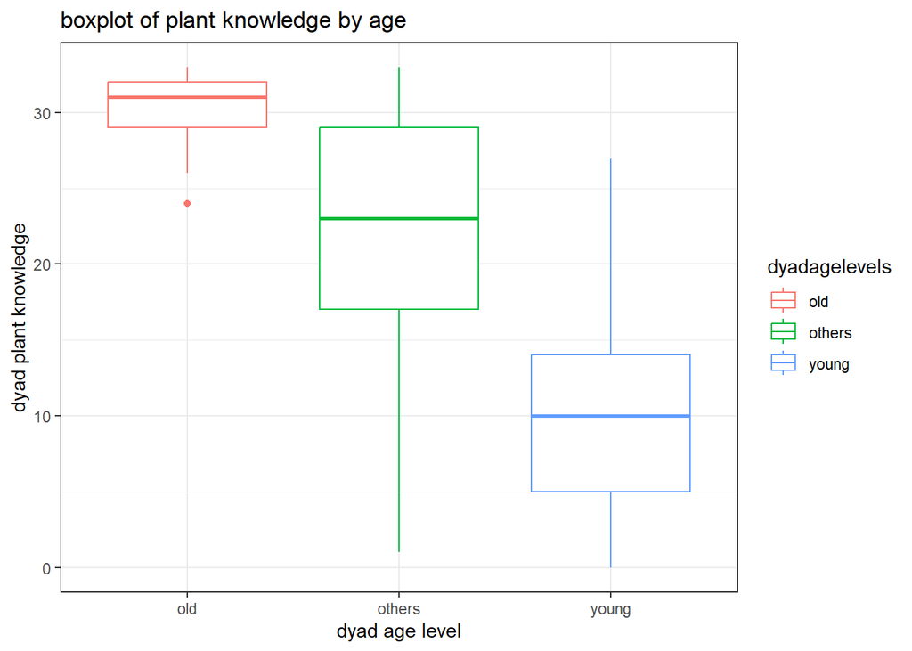

```r
ggplot() +
  geom_boxplot(data = know_age, mapping = aes(x = dyadagelevels, y = sum_know, colour = dyadagelevels)) +
  labs(x = "dyad age level", y = "dyad plant knowledge",
       title = "boxplot of plant knowledge by age") +
  theme_bw()
```

### Interpretation

From the p-value in the Kruskal-Walis test one sees that age levels are a valid predictor for total plant knowledge. Furthermore, the boxplot implies that age positively corelates with plant knowledge, meaning that older people have more knowledge.

## Sex

### Analysis

First, We apply the Kruskal-Wallis test again and wrangle the frame.

```r
# exclude NAs
know_sex <- dyads_merged %>%
  filter(dyadsex != "NANA") %>%
  group_by(dyad_ID, dyadsex) %>%
  summarise(sum_know = sum(dyadknow), n= n())

kruskal.test(sum_know ~ dyadsex, data = know_sex)
```

```
##
##  Kruskal-Wallis rank sum test
##
## data:  sum_know by dyadsex
## Kruskal-Wallis chi-squared = 881.85, df = 2, p-value < 2.2e-16
```

And second, we compare the different levels visually:

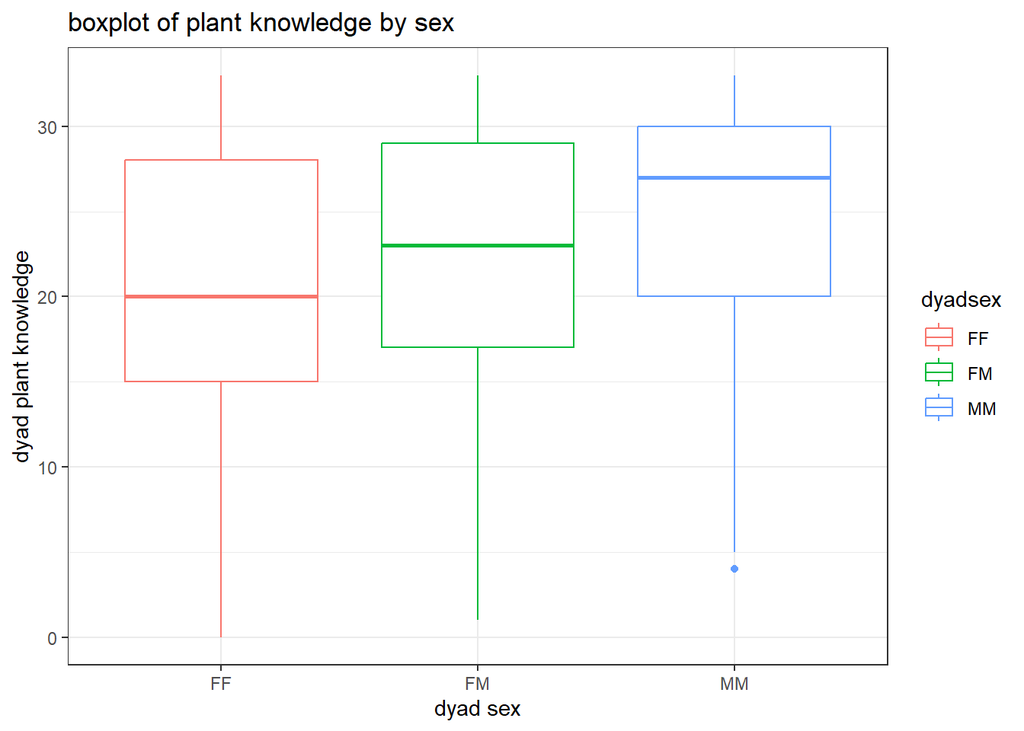

```r
ggplot() +
  geom_boxplot(data = know_sex, mapping = aes(x = dyadsex, y = sum_know, colour = dyadsex)) +
  labs(x = "dyad sex", y = "dyad plant knowledge",
       title = "boxplot of plant knowledge by sex") +
  theme_bw()
```

### Interpretation

From the p-value in the Kruskal-Walis test one sees that dyad sex is a valid predictor for total plant knowledge. Furthermore, the boxplot implies that men share more plant knowledge.

# Camp

## Analysis

First, We apply the Kruskal-Wallis test again and wrangle the frame.

```r
dyads_merged$dyadcamp <- ifelse(dyads_merged$camp1 == dyads_merged$camp2, "same", "different")

# how do I get rid of the NAs?
know_camp <- dyads_merged %>%
  # filter(!is.na(dyadcamp)) %>%
  group_by(dyad_ID, dyadcamp) %>%
  summarise(sum_know = sum(dyadknow), n= n()) # %>%

kruskal.test(sum_know ~ dyadcamp, data = know_camp)
```

```
##
##  Kruskal-Wallis rank sum test
##
## data:  sum_know by dyadcamp
## Kruskal-Wallis chi-squared = 9.6007, df = 1, p-value = 0.001945
```

And second, we compare the different levels visually:

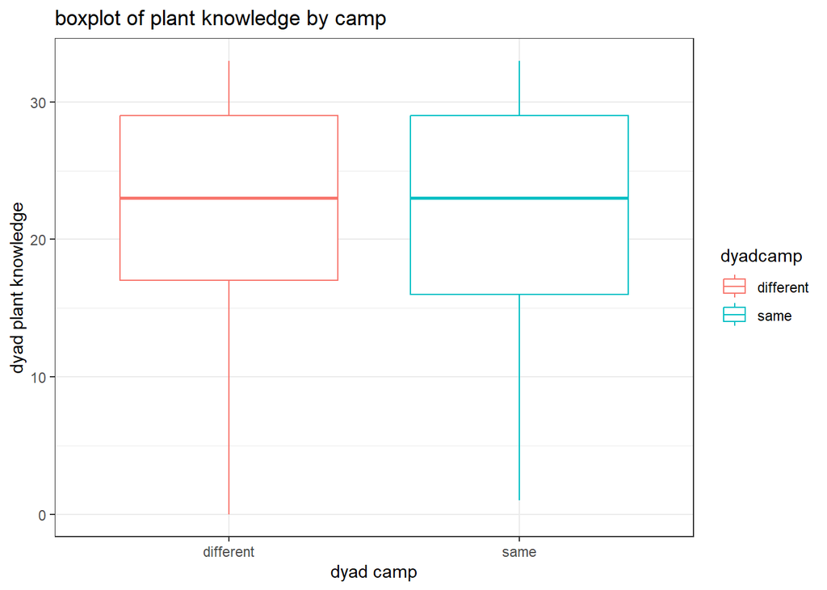

```r
ggplot() +
  geom_boxplot(data = know_camp, mapping = aes(x = dyadcamp, y = sum_know, colour = dyadcamp)) +
  labs(x = "dyad camp", y = "dyad plant knowledge",
       title = "boxplot of plant knowledge by camp") +
  theme_bw()
```

### Interpretation

The Kruskal Walis test implies a significant relationship between camp and sum of shared knowledge. This result needs to be treated with care, because the boxplot implies little significance.

# Regression analysis

We will lose a logistic glm model and run separate logistic regressions (i.e. not controlling for pseudoreplication) to predict shared knowledge as a function of dyadic:

- Age
- Sex
- Camp
- A multiplicative model with age, sex and their interaction (age*sex)

To start, we implement a function to convert the odds returned by `glm` to a probability. In principle getting probabilities out of a logistic regression is straightforward. We coefficients returned by the summaries are log-odds-ration, except for the baseline it is directly log-odds. To get the probability for any other level but baseline we simply add the log-odds-ration of the respective level.

```r
# column shared knowledge is called dyadknow
# function to convert odds into probabilities
odds2P <- function (odds){
  return (odds / (1 + odds))
}
```

## Age

### Regression

We build the model with one explanatory variable (age). Our baseline is “old” as it comes first in the alphabet.

```r
simplem_logreg_age <- glm(dyadknow ~ dyadagelevels, binomial, data = dyads_merged)
summary(simplem_logreg_age)
```

```
##
## Call:
## glm(formula = dyadknow ~ dyadagelevels, family = binomial, data = dyads_merged)
##
## Deviance Residuals:
##     Min       1Q   Median       3Q      Max
## -2.2439  -1.4946   0.8904   0.8904   1.5350
##
## Coefficients:
##                     Estimate Std. Error z value Pr(>|z|)
## (Intercept)          2.43336    0.04409   55.19   <2e-16 ***
## dyadagelevelsothers -1.71282    0.04416  -38.79   <2e-16 ***
## dyadagelevelsyoung  -3.24339    0.05059  -64.11   <2e-16 ***
## ---
## Signif. codes:  0 '***' 0.001 '**' 0.01 '*' 0.05 '.' 0.1 ' ' 1
##
## (Dispersion parameter for binomial family taken to be 1)
##
##     Null deviance: 992103  on 783386  degrees of freedom
## Residual deviance: 985462  on 783384  degrees of freedom
##   (4356 observations deleted due to missingness)
## AIC: 985468
##
## Number of Fisher Scoring iterations: 4
```

### Analysis

First, we rename the coefficient vector to access its values returned by the model more easily. Second, we extract the log-odds of the baseline provided by the model. And third, we calculate the log-odds of the other levels by adding the baseline odds.

```r
# coeficicents of model
coef_age <- coef(simplem_logreg_age)
names(coef_age) <- c("baseline", "others", "young")
# odds baseline = old: P(know) / P(not know)
odds_base <- exp(coef_age["baseline"])
# odds ratios of who is more likely to know plant vs baseline
ratio_other <- exp(coef_age["others"]) # others:old
ratio_young <- exp(coef_age["young"]) # young:old
# odds exposure groups: P(know) / P(not know)
odds_others <- exp(coef_age["others"] + coef_age["baseline"])
odds_young <- exp(coef_age["young"] + coef_age["baseline"])

# probabilities that groups share knowledge
odds_age <- c(odds2P(odds_others), odds2P(odds_young), odds2P(odds_base))
names(odds_age) <- c("P(other share)", "P(young share)", "P(old share)")

odds_age
```

```
## P(other share) P(young share)   P(old share)
##      0.6727252      0.3078840      0.9193362
```

### Interpretations

The probability that knowledge is shared in a dyad rises with the age level and the p-value indicates that this relationship is significant.

## Sex

### Regression

We build the model with one explanatory variable (sex). Our baseline is “Ff” as it comes first in the alphabet.

```r
simplem_logreg_sex <- glm(dyadknow ~ dyadsex, binomial, data = dyads_merged %>% filter(dyadsex != "NANA"))
summary(simplem_logreg_sex)
```

```
##
## Call:
## glm(formula = dyadknow ~ dyadsex, family = binomial, data = dyads_merged %>%
##     filter(dyadsex != "NANA"))
##
## Deviance Residuals:
##     Min       1Q   Median       3Q      Max
## -1.6484  -1.3873   0.8854   0.8854   0.9811
##
## Coefficients:
##             Estimate Std. Error z value Pr(>|z|)
## (Intercept) 0.481026   0.004276  112.50   <2e-16 ***
## dyadsexFM   0.253254   0.005479   46.22   <2e-16 ***
## dyadsexMM   0.580572   0.007141   81.30   <2e-16 ***
## ---
## Signif. codes:  0 '***' 0.001 '**' 0.01 '*' 0.05 '.' 0.1 ' ' 1
##
## (Dispersion parameter for binomial family taken to be 1)
##
##     Null deviance: 987349  on 780548  degrees of freedom
## Residual deviance: 980515  on 780546  degrees of freedom
## AIC: 980521
##
## Number of Fisher Scoring iterations: 4
```

### Analysis

First, we rename the coefficient vector to access its values returned by the model more easily. Second, we extract the log-odds of the baseline provided by the model. And third, we calculate the log-odds of the other levels by adding the baseline odds.

```r
coef_sex <- coef(simplem_logreg_sex)[1:3] ; names(coef_sex) <- c("baseline", "FM", "MM")
# odds baseline: P(know) / P(not know)
odds_FF <- exp(coef_sex["baseline"])
# odds ratios of who is more likely to know plant vs baseline
ratio_FM <- exp(coef_sex["FM"]) # FM:FF
ratio_MM <- exp(coef_sex["MM"]) # MM:FF
# odds exposure groups: P(know) / P(not know)
odds_FM <- exp(coef_sex["FM"] + coef_sex["baseline"])
odds_MM <- exp(coef_sex["MM"] + coef_sex["baseline"])
# probalities that groups shares knowledge
odds_sex <- c(odds2P(odds_FF),odds2P(odds_FM), odds2P(odds_MM))
names(odds_sex) <- c("P(FF share)", "P(FM share)", "P(MM share)")

odds_sex
```

```
## P(FF share) P(FM share) P(MM share)
##   0.6179902   0.6757439   0.7429958
```

### Interpretation

The probability that knowledge is shared rises when a man is part of the dyad.

## Camp

We repeat the workflow above for camp:

### Regression

```r
simplem_logreg_camp <- glm(dyadknow ~ dyadcamp, binomial, data = dyads_merged)
summary(simplem_logreg_camp)
```

```
##
## Call:
## glm(formula = dyadknow ~ dyadcamp, family = binomial, data = dyads_merged)
##
## Deviance Residuals:
##     Min       1Q   Median       3Q      Max
## -1.4972  -1.4725   0.8883   0.8883   0.9086
##
## Coefficients:
##               Estimate Std. Error z value Pr(>|z|)
## (Intercept)   0.726272   0.002795  259.86   <2e-16 ***
## dyadcampsame -0.054878   0.005440  -10.09   <2e-16 ***
## ---
## Signif. codes:  0 '***' 0.001 '**' 0.01 '*' 0.05 '.' 0.1 ' ' 1
##
## (Dispersion parameter for binomial family taken to be 1)
##
##     Null deviance: 998225  on 787742  degrees of freedom
## Residual deviance: 998123  on 787741  degrees of freedom
## AIC: 998127
##
## Number of Fisher Scoring iterations: 4
```

### Analysis

```r
coef_camp <- coef(simplem_logreg_camp) ; names(coef_camp) <- c("baseline", "same")
# odds baseline: P(know) / P(not know)
odds_diff <- exp(coef_camp["baseline"])
# odds ratios of who is more likely to know plant vs baseline
ratio_sampe <- exp(coef_camp["same"]) # same:diff
# odds exposure groups: P(know) / P(not know)
odds_same <- exp(coef_camp["same"] + coef_camp["baseline"])

# probalities that groups share knowledge
odds_camp <- c(odds2P(odds_diff), odds2P(odds_same))
names(odds_camp) <- c("P(different camp share)", "P(same camp share)")

odds_camp
```

```
## P(different camp share)      P(same camp share)
##               0.6739867               0.6618153
```

### Interpretation

Camp doesn’t seem to be a valid predictor for shared knowledge because probability that knowledge is shared by people in same camp is similar to the one of dyads not belonging to the same camp.

## Multiplicative

Finally, we build a multiplicative model between age and sex to find out whether an interaction consideration provides additional information. We continue with the workflow above.

### Regression

```r
simplem_logreg_agexsex <- glm(dyadknow ~ dyadagelevels * dyadsex, binomial, data = dyads_merged %>% filter(dyadsex != "NANA"))
summary(simplem_logreg_agexsex)
```

```
##
## Call:
## glm(formula = dyadknow ~ dyadagelevels * dyadsex, family = binomial,
##     data = dyads_merged %>% filter(dyadsex != "NANA"))
##
## Deviance Residuals:
##     Min       1Q   Median       3Q      Max
## -2.5433  -1.3813   0.8813   0.8813   1.6313
##
## Coefficients:
##                               Estimate Std. Error z value Pr(>|z|)
## (Intercept)                    2.28138    0.05480  41.631  < 2e-16 ***
## dyadagelevelsothers           -1.81390    0.05497 -32.998  < 2e-16 ***
## dyadagelevelsyoung            -3.30507    0.08563 -38.598  < 2e-16 ***
## dyadsexFM                      0.33956    0.09485   3.580 0.000344 ***
## dyadsexMM                      0.91257    0.28816   3.167 0.001541 **
## dyadagelevelsothers:dyadsexFM -0.06161    0.09501  -0.649 0.516660
## dyadagelevelsyoung:dyadsexFM  -0.15738    0.12065  -1.304 0.192079
## dyadagelevelsothers:dyadsexMM -0.27123    0.28825  -0.941 0.346724
## dyadagelevelsyoung:dyadsexMM  -0.56112    0.29849  -1.880 0.060129 .
## ---
## Signif. codes:  0 '***' 0.001 '**' 0.01 '*' 0.05 '.' 0.1 ' ' 1
##
## (Dispersion parameter for binomial family taken to be 1)
##
##     Null deviance: 981221  on 776192  degrees of freedom
## Residual deviance: 966471  on 776184  degrees of freedom
##   (4356 observations deleted due to missingness)
## AIC: 966489
##
## Number of Fisher Scoring iterations: 5
```

### Analysis

In a multiplicative model it can be quite cumbersome to calculate the probabilities of all the combinations. First, we identify our baseline which is oldFF. From there we slowly build up to higher complexity. Calculating the probability of levels that differ from the baseline in only one explanatory variable are still intuitively calculatable. We simply add the log-odds ration of the respective level to the baseline. However, for levels differing in two explanatory variables from the baseline we need to understand how the model calculated the log-odd ratios. It’s like climbing up a stairway to the respective level, where the baseline is the bottom log-odds and every stair the log-odds-ration of a combination relative to the baseline. For instance, the log-odds for young and male-male dyads are calculated by adding the log-odds ratios of old, MM (MM differs from baseline) and young, FF (young differs from baseline). Next, we add the log odds ratio for young, MM, differing in two.

```r
# the baseline is oldFF
coef_mult <- coef(simplem_logreg_agexsex)
names(coef_mult) <-c("baseline",
                     "othersFF",
                     "youngFF",
                     "oldFM",
                     "oldMM",
                     "othersFM",
                     "youngFM",
                     "othersMM",
                     "youngMM")

# calculate probabilities
odds_mul <- c(odds2P(exp(coef_mult["youngFF"] + coef_mult["baseline"])),
              odds2P(exp(coef_mult["othersFF"] + coef_mult["baseline"])),
              odds2P(exp(coef_mult["baseline"])),
              odds2P(exp(coef_mult["oldFM"] + coef_mult["baseline"])),
              odds2P(exp(coef_mult["oldMM"] + coef_mult["baseline"])),
              odds2P(exp(coef_mult["othersFM"] + coef_mult["oldFM"] +
                         coef_mult["othersFF"] + coef_mult["baseline"])),
              odds2P(exp(coef_mult["youngFM"] + coef_mult["youngFF"] +
                         coef_mult["oldFM"] + coef_mult["baseline"])),
              odds2P(exp(coef_mult["othersMM"] + coef_mult["othersFF"] +
                         coef_mult["oldMM"] + coef_mult["baseline"])),
              odds2P(exp(coef_mult["youngMM"] + coef_mult["youngFF"] +
                         coef_mult["oldMM"] + coef_mult["baseline"]))


              )

names(odds_mul) <- c("P(share young,FF)",
                     "P(share other,FF)",
                     "P(share old,FF)",
                     "P(share old,FM)",
                     "P(share old,MM)",
                     "P(share others, FM)",
                     "P(share young,FM)",
                     "P(share others,MM)",
                     "P(share young,MM)"
                     )

odds_mul
```

```
##   P(share young,FF)   P(share other,FF)     P(share old,FF)     P(share old,FM)
##           0.2643098           0.6147873           0.9073232           0.9321970
##     P(share old,MM) P(share others, FM)   P(share young,FM)  P(share others,MM)
##           0.9606061           0.6781807           0.3012173           0.7519092
##   P(share young,MM)
##           0.3379953
```

### Interpretation

Because the interaction is not significant, we see that the probabilities for P(share young, FM) or P(share young, MM) do not differ significantly from the calculated P(share young, FF). In the same sense for P(share others, FF) and the combined probabilities for the two other age levels or all other possible combinations. This is the conceptual meaning for a non-significant interaction for logistic regression performed up on multiple levels!

## Optimization

In closing we use the step function on a logistic model with all three explanatory variables to find out whether one can be droppend according to the AIC.

```r
summary(step(glm(dyadknow ~ dyadagelevels + dyadsex + dyadcamp, binomial, data = dyads_merged %>% filter(dyadsex != "NANA"))))
```

```
## Start:  AIC=966396.7
## dyadknow ~ dyadagelevels + dyadsex + dyadcamp
##
##                 Df Deviance    AIC
## <none>               966385 966397
## - dyadcamp       1   966491 966501
## - dyadagelevels  2   973982 973990
## - dyadsex        2   974474 974482
```

```
##
## Call:
## glm(formula = dyadknow ~ dyadagelevels + dyadsex + dyadcamp,
##     family = binomial, data = dyads_merged %>% filter(dyadsex !=
##         "NANA"))
##
## Deviance Residuals:
##     Min       1Q   Median       3Q      Max
## -2.4540  -1.3880   0.8755   0.8965   1.7160
##
## Coefficients:
##                      Estimate Std. Error z value Pr(>|z|)
## (Intercept)          2.321543   0.044189   52.54   <2e-16 ***
## dyadagelevelsothers -1.839046   0.044229  -41.58   <2e-16 ***
## dyadagelevelsyoung  -3.476119   0.050781  -68.45   <2e-16 ***
## dyadsexFM            0.278780   0.005517   50.53   <2e-16 ***
## dyadsexMM            0.638983   0.007242   88.23   <2e-16 ***
## dyadcampsame        -0.057205   0.005534  -10.34   <2e-16 ***
## ---
## Signif. codes:  0 '***' 0.001 '**' 0.01 '*' 0.05 '.' 0.1 ' ' 1
##
## (Dispersion parameter for binomial family taken to be 1)
##
##     Null deviance: 981221  on 776192  degrees of freedom
## Residual deviance: 966385  on 776187  degrees of freedom
##   (4356 observations deleted due to missingness)
## AIC: 966397
##
## Number of Fisher Scoring iterations: 4
```

The step function suggests that the best AIC is obtained if all features are kept in the model.

# Mixed Effect Models

Mixed Effect Models are proven to improve a models power as it included random effects along fixed effects. Here, we analyse the merged dyad data set with a mixed effect models of the levels: * age * sex * camp * multiplicative age and sex

## Choice of random effect: learned from the same realtionship

We choose the random effect on whether the dyad learned the plant from the degree of a relative.

```r
dyads_merged$samelearned <- ifelse(dyads_merged$learned1 == dyads_merged$learned2, 1, 0)
# dyads_merged$sameborn <- ifelse(dyads_merged$born1 == dyads_merged$born2, 1, 0)
# variance components analysis?
```

## Age

We build the model including the random effect

```r
mixedm_logreg_age <- glmer(dyadknow ~ dyadagelevels + (1|samelearned), family = binomial, data = dyads_merged)
summary(mixedm_logreg_age)
```

```
## Generalized linear mixed model fit by maximum likelihood (Laplace
##   Approximation) [glmerMod]
##  Family: binomial  ( logit )
## Formula: dyadknow ~ dyadagelevels + (1 | samelearned)
##    Data: dyads_merged
##
##       AIC       BIC    logLik  deviance  df.resid
##  859793.3  859839.1 -429892.7  859785.3    692831
##
## Scaled residuals:
##     Min      1Q  Median      3Q     Max
## -3.3178 -1.4823  0.6746  0.6746  1.4550
##
## Random effects:
##  Groups      Name        Variance Std.Dev.
##  samelearned (Intercept) 0.001514 0.03892
## Number of obs: 692835, groups:  samelearned, 2
##
## Fixed effects:
##                     Estimate Std. Error z value Pr(>|z|)
## (Intercept)          2.35996    0.02550   92.54   <2e-16 ***
## dyadagelevelsothers -1.61141    0.02061  -78.19   <2e-16 ***
## dyadagelevelsyoung  -3.07138    0.02371 -129.55   <2e-16 ***
## ---
## Signif. codes:  0 '***' 0.001 '**' 0.01 '*' 0.05 '.' 0.1 ' ' 1
##
## Correlation of Fixed Effects:
##             (Intr) dydglvlst
## dydglvlsthr -0.561
## dydglvlsyng -0.253  0.438
```

### Analysis

As in the simple regression we extract and convert the model output to interpretable probabilities

```r
# coeficicents of model
coef_age <- coef(mixedm_logreg_age)$samelearned[1,]; names(coef_age) <- c("baseline", "others", "young")
# odds baseline = old: P(know) / P(not know)
odds_base <- exp(coef_age["baseline"])
# odds ratios of who is more likely to know plant vs baseline
ratio_other <- exp(coef_age["others"]) # others:old
ratio_young <- exp(coef_age["young"]) # young:old
# odds exposure groups: P(know) / P(not know)
odds_others <- exp(coef_age["others"] + coef_age["baseline"])
odds_young <- exp(coef_age["young"] + coef_age["baseline"])

# probabilities that groups share knowledge
odds_age <- c(odds2P(odds_others), odds2P(odds_young), odds2P(odds_base))
names(odds_age) <- c("P(other share)", "P(young share)", "P(old share)")

odds_age
```

```
## $`P(other share)`
## [1] 0.6872229
##
## $`P(young share)`
## [1] 0.337869
##
## $`P(old share)`
## [1] 0.9167188
```

## Sex

```r
mixedm_logreg_sex <- glmer(dyadknow ~ dyadsex + (1|samelearned), family = binomial, data = dyads_merged %>% filter(dyadsex != "NANA"))
summary(mixedm_logreg_sex)
```

```
## Generalized linear mixed model fit by maximum likelihood (Laplace
##   Approximation) [glmerMod]
##  Family: binomial  ( logit )
## Formula: dyadknow ~ dyadsex + (1 | samelearned)
##    Data: dyads_merged %>% filter(dyadsex != "NANA")
##
##       AIC       BIC    logLik  deviance  df.resid
##  854077.6  854123.4 -427034.8  854069.6    690026
##
## Scaled residuals:
##     Min      1Q  Median      3Q     Max
## -1.7582 -1.3228  0.6721  0.6721  0.8030
##
## Random effects:
##  Groups      Name        Variance Std.Dev.
##  samelearned (Intercept) 0.003672 0.0606
## Number of obs: 690030, groups:  samelearned, 2
##
## Fixed effects:
##             Estimate Std. Error z value Pr(>|z|)
## (Intercept) 0.499137   0.033754   14.79   <2e-16 ***
## dyadsexFM   0.235036   0.005920   39.70   <2e-16 ***
## dyadsexMM   0.568967   0.007392   76.97   <2e-16 ***
## ---
## Signif. codes:  0 '***' 0.001 '**' 0.01 '*' 0.05 '.' 0.1 ' ' 1
##
## Correlation of Fixed Effects:
##           (Intr) dydsFM
## dyadsexFM -0.038
## dyadsexMM -0.030  0.476
```

### Analysis

```r
coef_sex <- coef(mixedm_logreg_sex)$samelearned[1,] ; names(coef_sex) <- c("baseline", "FM", "MM")
# odds baseline: P(know) / P(not know)
odds_FF <- exp(coef_sex["baseline"])
# odds ratios of who is more likely to know plant vs baseline
ratio_FM <- exp(coef_sex["FM"]) # FM:FF
ratio_MM <- exp(coef_sex["MM"]) # MM:FF
# odds exposure groups: P(know) / P(not know)
odds_FM <- exp(coef_sex["FM"] + coef_sex["baseline"])
odds_MM <- exp(coef_sex["MM"] + coef_sex["baseline"])
# probalities that groups shares knowledge
odds_sex <- c(odds2P(odds_FF),odds2P(odds_FM), odds2P(odds_MM))
names(odds_sex) <- c("P(FF share)", "P(FM share)", "P(MM share)")

odds_sex
```

```
## $`P(FF share)`
## [1] 0.6363502
##
## $`P(FM share)`
## [1] 0.6888168
##
## $`P(MM share)`
## [1] 0.7555666
```

## Camp

```r
mixedm_logreg_camp <- glmer(dyadknow ~ dyadcamp + (1|samelearned), family = binomial, data = dyads_merged)
summary(mixedm_logreg_camp)
```

```
## Generalized linear mixed model fit by maximum likelihood (Laplace
##   Approximation) [glmerMod]
##  Family: binomial  ( logit )
## Formula: dyadknow ~ dyadcamp + (1 | samelearned)
##    Data: dyads_merged
##
##       AIC       BIC    logLik  deviance  df.resid
##  870101.3  870135.7 -435047.7  870095.3    696792
##
## Scaled residuals:
##     Min      1Q  Median      3Q     Max
## -1.4862 -1.4579  0.6728  0.6859  0.7150
##
## Random effects:
##  Groups      Name        Variance Std.Dev.
##  samelearned (Intercept) 0.001749 0.04182
## Number of obs: 696795, groups:  samelearned, 2
##
## Fixed effects:
##               Estimate Std. Error z value Pr(>|z|)
## (Intercept)   0.750923   0.019596  38.321  < 2e-16 ***
## dyadcampsame -0.038425   0.005741  -6.694 2.18e-11 ***
## ---
## Signif. codes:  0 '***' 0.001 '**' 0.01 '*' 0.05 '.' 0.1 ' ' 1
##
## Correlation of Fixed Effects:
##             (Intr)
## dyadcampsam -0.039
```

### Analysis

```r
coef_camp <- coef(mixedm_logreg_camp)$samelearned[1,] ; names(coef_camp) <- c("baseline", "same")
# odds baseline: P(know) / P(not know)
odds_diff <- exp(coef_camp["baseline"])
# odds ratios of who is more likely to know plant vs baseline
ratio_sampe <- exp(coef_camp["same"]) # same:diff
# odds exposure groups: P(know) / P(not know)
odds_same <- exp(coef_camp["same"] + coef_camp["baseline"])
# probalities that groups share knowledge
odds_camp <- c(odds2P(odds_diff), odds2P(odds_same))
names(odds_camp) <- c("P(different camp share)", "P(same camp share)")

odds_camp
```

```
## $`P(different camp share)`
## [1] 0.6883597
##
## $`P(same camp share)`
## [1] 0.6800577
```

## Multiplicative

```r
mixedm_logreg_agexsex <- glmer(dyadknow ~ dyadagelevels * dyadsex + (1|samelearned), family = binomial, data = dyads_merged %>% filter(dyadsex != "NANA"))
summary(mixedm_logreg_agexsex)
```

```
## Generalized linear mixed model fit by maximum likelihood (Laplace
##   Approximation) [glmerMod]
##  Family: binomial  ( logit )
## Formula: dyadknow ~ dyadagelevels * dyadsex + (1 | samelearned)
##    Data: dyads_merged %>% filter(dyadsex != "NANA")
##
##       AIC       BIC    logLik  deviance  df.resid
##  842671.0  842785.4 -421325.5  842651.0    686060
##
## Scaled residuals:
##     Min      1Q  Median      3Q     Max
## -4.9381 -1.3112  0.6701  0.6701  1.5367
##
## Random effects:
##  Groups      Name        Variance Std.Dev.
##  samelearned (Intercept) 0.003289 0.05735
## Number of obs: 686070, groups:  samelearned, 2
##
## Fixed effects:
##                               Estimate Std. Error  z value Pr(>|z|)
## (Intercept)                    2.17130    0.02796   77.662  < 2e-16 ***
## dyadagelevelsothers           -1.68659    0.02329  -72.423  < 2e-16 ***
## dyadagelevelsyoung            -2.97346    0.02747 -108.233  < 2e-16 ***
## dyadsexFM                      0.36331    0.02742   13.248  < 2e-16 ***
## dyadsexMM                      1.07980    0.03037   35.555  < 2e-16 ***
## dyadagelevelsothers:dyadsexFM -0.10450    0.02749   -3.801 0.000144 ***
## dyadagelevelsyoung:dyadsexFM  -0.32076    0.03192  -10.048  < 2e-16 ***
## dyadagelevelsothers:dyadsexMM -0.45246    0.03054  -14.814  < 2e-16 ***
## dyadagelevelsyoung:dyadsexMM  -0.92198    0.04147  -22.230  < 2e-16 ***
## ---
## Signif. codes:  0 '***' 0.001 '**' 0.01 '*' 0.05 '.' 0.1 ' ' 1
##
## Correlation of Fixed Effects:
##              (Intr) dydglvlst dydglvlsy dydsFM dydsMM dydglvlst:FM dydglvlsy:FM
## dydglvlsthr  -0.328
## dydglvlsyng  -0.194  0.348
## dyadsexFM    -0.060  0.211    -0.028
## dyadsexMM    -0.043  0.108    -0.103     0.068
## dydglvlst:FM  0.054 -0.226     0.030    -0.976 -0.056
## dydglvlsy:FM  0.007  0.103    -0.267    -0.329  0.115  0.326
## dydglvlst:MM  0.037 -0.122     0.104    -0.056 -0.969  0.070       -0.113
## dydglvlsy:MM  0.068  0.180    -0.107    -0.010 -0.445  0.005        0.032
##              dydglvlst:MM
## dydglvlsthr
## dydglvlsyng
## dyadsexFM
## dyadsexMM
## dydglvlst:FM
## dydglvlsy:FM
## dydglvlst:MM
## dydglvlsy:MM  0.432
```

### Analysis

In a multiplicative model it can be quite cumbersome to calculate the probabilities of all the combinations. First, we identify our baseline which is oldFF. From there we slowly build up to higher complexity. Calculating the probability of levels that differ from the baseline in only one explanatory variable are still intuitively calculatable. We simply add the log-odds ration of the respective level to the baseline. However, for levels differing in two explanatory variables from the baseline we need to understand how the model calculated the log-odd ratios. It’s like climbing up a stairway to the respective level, where the baseline is the bottom log-odds and every stair the log-odds-ration of a combination relative to the baseline. For instance, the log-odds for young and male-male dyads are calculated by adding the log-odds ratios of old, MM (MM differs from baseline) and young, FF (young differs from baseline). Next, we add the log odds ratio for young, MM, differing in two.

```r
# the baseline is oldFF
coef_mult <- coef(mixedm_logreg_agexsex)$samelearned[1,] # the baseline is oldFF

names(coef_mult) <-c("baseline",
                     "othersFF",
                     "youngFF",
                     "oldFM",
                     "oldMM",
                     "othersFM",
                     "youngFM",
                     "othersMM",
                     "youngMM")

# calculate probabilities
odds_mul <- c(odds2P(exp(coef_mult["youngFF"] + coef_mult["baseline"])),
              odds2P(exp(coef_mult["othersFF"] + coef_mult["baseline"])),
              odds2P(exp(coef_mult["baseline"])),
              odds2P(exp(coef_mult["oldFM"] + coef_mult["baseline"])),
              odds2P(exp(coef_mult["oldMM"] + coef_mult["baseline"])),
              odds2P(exp(coef_mult["othersFM"] + coef_mult["oldFM"] +
                         coef_mult["othersFF"] + coef_mult["baseline"])),
              odds2P(exp(coef_mult["youngFM"] + coef_mult["youngFF"] +
                         coef_mult["oldFM"] + coef_mult["baseline"])),
              odds2P(exp(coef_mult["othersMM"] + coef_mult["othersFF"] +
                         coef_mult["oldMM"] + coef_mult["baseline"])),
              odds2P(exp(coef_mult["youngMM"] + coef_mult["youngFF"] +
                         coef_mult["oldMM"] + coef_mult["baseline"]))


              )

names(odds_mul) <- c("P(share young,FF)",
                     "P(share other,FF)",
                     "P(share old,FF)",
                     "P(share old,FM)",
                     "P(share old,MM)",
                     "P(share others, FM)",
                     "P(share young,FM)",
                     "P(share others,MM)",
                     "P(share young,MM)"
                     )

odds_mul
```

```
## $`P(share young,FF)`
## [1] 0.3219135
##
## $`P(share other,FF)`
## [1] 0.6322491
##
## $`P(share old,FF)`
## [1] 0.9027773
##
## $`P(share old,FM)`
## [1] 0.9303309
##
## $`P(share old,MM)`
## [1] 0.9647115
##
## $`P(share others, FM)`
## [1] 0.6901214
##
## $`P(share young,FM)`
## [1] 0.3312706
##
## $`P(share others,MM)`
## [1] 0.7630035
##
## $`P(share young,MM)`
## [1] 0.3572843
```

### Interpretation

The random effect had a significant effect on the model even though it explains little variance amount. The interaction terms are now classified as significant, which means that for example P(share young,FM) does vary significantly from P(share old,FF) and P(others, FF). Thus, the random effect gave the model more explanatory power and certainty.

# Conclusion

Overall, the result seems to be coherent over the analysis through basic test and boxplots over simple logistic regression to the mixed regression models. The hypothesis resulting from exploring the data in 4) are confirmed in the built model of 5) and 6). From the simple model it becomes clear that sex and age are valid predictors for shared plant knowledge, since probability of shared knowledge in dyads increase with age or fraction of males in the dyad. However, being in the same camp doesn’t increase the probability for sharing knowledge. General trends are that the models with interactions show lower AICs and thus have greater explanatory power than single-level ones. Moreover, in the mixed models, the random effect describing the shared source of learnt content brings more certainty in the probabilities and further lowers the AIC in the model. Thus, the model with the greatest explanatory power is the one of 6e), a two level mixed effect model. From the probabilities resutling from the single level models I would rank the factors in importance as follows: 1. age, 2. sex and 3. camp.